# Business Problem

Detecting gender from an audio file.

# Data Source

Using a dataset from Google available at:

https://research.google.com/audioset/

The traininig dataset will be from youtube audio files totaling 10 minutes, being 5 for each gender, each spoken by 5 different people, so 1 minute per person (5 male and 5 female)

The testing dataset was extracted from "AudioSet", a corpus containing 558 speech expressions spoken by women and 546 spoken by men. Each audio file has 10 seconds and is sampled at 16000 Hz.

# Packages

```python
# Imports

# Data manipulation and visualization
import os
import matplotlib
import numpy as np
import pickle as cPickle
import matplotlib.pyplot as plt

# Feature extraction
import scipy
import librosa
import python_speech_features as psf
from scipy.io import wavfile

# Model training
import sklearn
from sklearn import preprocessing
from sklearn.mixture import GaussianMixture as GMM

# Audio Recording
import sounddevice as sd
import soundfile as sf
```

```python
# Package versions
%reload_ext watermark
%watermark --iversions
```

```
matplotlib  3.2.2
sklearn     0.23.1
sounddevice 0.3.15
librosa     0.7.2
numpy       1.18.5
scipy       1.5.0
soundfile   0.10.3
```

# Loading Data

There will be two models, one for male data and another for female data. The audio files are already split accordingly.

**Audio Files - Male Voices**

```python
# Path for the training data with male voices
train_voice_m = 'data/train/youtube/male'
```

```python
# Create lite with all files
list_files_m = [os.path.join(train_voice_m, f) for f in os.listdir(train_voice_m) if f.endswith('.wav')]
```

```python
# Check list content
list_files_m
```

```
['data/train/youtube/male\\male1.wav',
 'data/train/youtube/male\\male2.wav',
 'data/train/youtube/male\\male3.wav',
 'data/train/youtube/male\\male4.wav',
 'data/train/youtube/male\\male5.wav']
```

```python
# Object type
type(list_files_m)
```

```
list
```

**Audio Files - Female Voices**

```python
# Path for the training data with female voices
train_voice_f = 'data/train/youtube/female'
```

```python
# Create lite with all files
list_files_f = [os.path.join(train_voice_f, f) for f in os.listdir(train_voice_f) if f.endswith('.wav')]
```

```python
# Check list content
list_files_f
```

```
['data/train/youtube/female\\female1.wav',
 'data/train/youtube/female\\female2.wav',
 'data/train/youtube/female\\female3.wav',
 'data/train/youtube/female\\female4.wav',
 'data/train/youtube/female\\female5.wav']
```

```python
# Object type
type(list_files_f)
```

```
list
```

# Extracting MFCC Features

Using the python_speech_features package: https://python-speech-features.readthedocs.io/en/latest/

It has a function to extract the MFCC features from audio files.

```python
# Function to extract MFCC features and scale them
def extract_mfcc(sr, audio):

    # Extract features from audio frames
    features = psf.mfcc(audio, sr,
                        winlen = 0.025, winstep = 0.01,
                        numcep = 13, appendEnergy = True)

    # Standardizing (scaling) features
    features = preprocessing.scale(features)

    return features
```

```python
# Creating arrays to receive the extracted features
features_m = np.asarray(())
features_f = np.asarray(())
```

```python
# Extrating features for the male audio files
for file_m in list_files_m:

    # Read the audio file
    sr, audio = wavfile.read(file_m)

    # Extract the feature vector
    feature_vector = extract_mfcc(sr, audio)

    # Check the size of the array created on the previous cell
    # If it's zero, include the first feature vector
    # If it's above zero, append
    # Needed to to this because otherwise the np.vstack method would bug on the first feature vector
    if features_m.size == 0:
        features_m = feature_vector
    else:
        features_m = np.vstack((features_m, feature_vector))
```

```python
# Extracted features
features_m
```

```
array([[-2.17442346, -0.55387187,  0.14534254, ..., -0.17595846,
        -0.69355552,  1.06524329],
       [-2.20149991, -0.47781889,  0.48374196, ..., -0.38345243,
        -0.76356038,  1.13956846],
       [-2.18603295, -0.62058102,  0.21628953, ...,  0.10395744,
        -0.56469634,  0.79154986],
       ...,
       [-2.06799885, -1.14589413,  0.65274852, ...,  1.13735423,
         0.23905922,  0.33625924],
       [-2.1203576 , -1.03779545,  0.83049988, ...,  0.95875965,
         0.65757472,  0.85409856],
       [-2.27073073, -0.88582047,  1.07441446, ...,  0.98584747,
         0.46769639,  0.68195901]])
```

```python
# Extrating features for the female audio files
for file_f in list_files_f:

    # Read the audio file
    sr, audio = wavfile.read(file_f)

    # Extract the feature vector
    feature_vector = extract_mfcc(sr, audio)

    # Check the size of the array created on the previous cell
    # If it's zero, include the first feature vector
    # If it's above zero, append
    # Needed to to this because other the np.vstack method would bug on the first feature vector
    if features_f.size == 0:
        features_f = feature_vector
    else:
        features_f = np.vstack((features_f, feature_vector))
```

```python
# Extracted features
features_f
```

```
array([[ 0.39577634,  0.5179585 ,  0.95218191, ...,  1.33169242,
         1.16834709, -1.3924513 ],
       [ 0.18475744,  1.2545105 ,  0.9253783 , ...,  0.33311528,
         0.8407119 , -1.86215752],
       [-0.21848578,  0.89438619,  1.35277608, ...,  0.53590941,
         0.25581686, -1.11834446],
       ...,
       [-1.74177759, -0.22278724,  0.62891626, ..., -0.16816487,
        -0.5033839 , -1.81041936],
       [-1.50532737, -0.37325447,  0.51987615, ..., -1.02577787,
        -0.96314989, -2.67721113],
       [-1.6352069 , -0.39439019,  0.65016017, ..., -1.2399293 ,
        -0.41338792, -1.87413114]])
```

# MFCC Feature Visualization

```python
len(features_m)
```

```
30169
```

```python
len(features_f)
```

```
30065
```

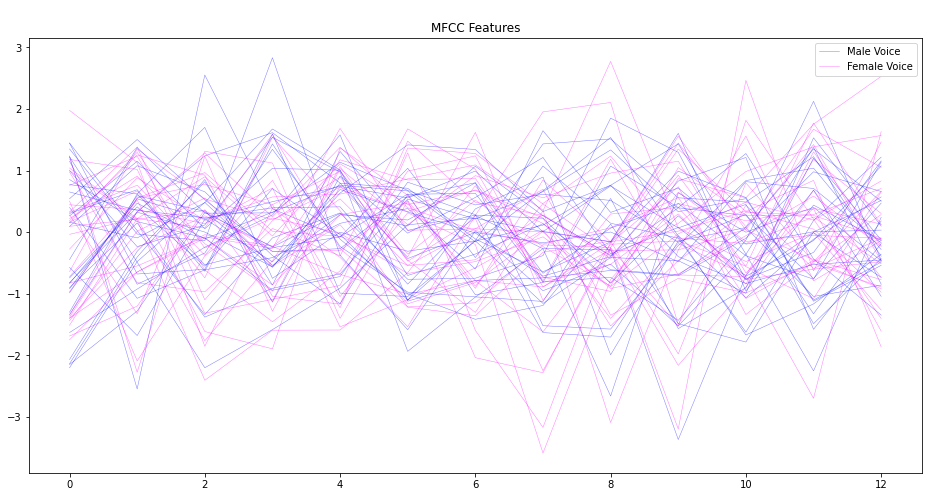

```python
# Plot to visualize the features as signals

# PLot area
plt.figure(figsize = (16, 8))

# Loop through the features
for i in range(1, 30000, 1000):
    plt.plot(features_m[i], c = 'blue', linewidth = 0.5, alpha = 0.5)
    plt.plot(features_f[i], c = 'magenta', linewidth = 0.5, alpha = 0.5)

# Plot
plt.plot(features_m[i+1], c = 'blue', label = 'Male Voice', linewidth = 0.5, alpha = 0.5)
plt.plot(features_f[i+1], c = 'magenta', label = 'Female Voice', linewidth = 0.5, alpha = 0.5)
plt.legend()
plt.title('\nMFCC Features')
plt.show()
```

# Machine Learning

Using Gaussian Mixture Model. This is a unsupervised algorithm.

From Wikipedia: In statistics, a mixture model is a probabilistic model for representing the presence of subpopulations within an overall population, without requiring that an observed data set should identify the sub-population to which an individual observation belongs.

The idea behind using a GMM is aproximating the probabily distribution of a class by a linear combination of 'k' Gaussian groups, also known as the GMM components.

Essentially it groups together samples which when grouped form a normal distribuiton

https://scikit-learn.org/stable/modules/generated/sklearn.mixture.GaussianMixture.html

**Model for Male Voices**

```python
# Create model
model_gmm_m = GMM(n_components = 8, max_iter = 200, covariance_type = 'diag', n_init = 3)
```

```python
%%time

# Train model
model_gmm_m.fit(features_m)
```

```
Wall time: 1.83 s
```

```
GaussianMixture(covariance_type='diag', max_iter=200, n_components=8, n_init=3)
```

```python
# Save model to disk
cPickle.dump(model_gmm_m, open('models/'+'model_gmm_m', 'wb'))
```

**Model for Female Voices**

```python
# Create model
model_gmm_f = GMM(n_components = 8, max_iter = 200, covariance_type = 'diag', n_init = 3)
```

```python
%%time

# Train model
model_gmm_f.fit(features_f)
```

```
Wall time: 1.51 s
```

```
GaussianMixture(covariance_type='diag', max_iter=200, n_components=8, n_init=3)
```

```python
# Save model to disk
cPickle.dump(model_gmm_f, open('models/'+'model_gmm_f', 'wb'))
```

# Model Evaluation

## Loading Test Data

```python
# Path for the test data
test_voice_m = 'data/test/AudioSet/male_clips'
test_voice_f = 'data/test/AudioSet/female_clips'
```

```python
# Create lite with all files
list_test_m = [os.path.join(test_voice_m, f) for f in os.listdir(test_voice_m) if f.endswith('.wav')]
list_test_f = [os.path.join(test_voice_f, f) for f in os.listdir(test_voice_f) if f.endswith('.wav')]
```

```python
# Sample test data
list_test_m[:3]
```

```
['data/test/AudioSet/male_clips\\-0CAdy06NRo.wav',
 'data/test/AudioSet/male_clips\\-0DO0ulATPY.wav',
 'data/test/AudioSet/male_clips\\-0kDcUEDfmY.wav']
```

```python
# Sample test data
list_test_f[:3]
```

```
['data/test/AudioSet/female_clips\\--EQQVMYe50.wav',
 'data/test/AudioSet/female_clips\\--IHiTgsaIk.wav',
 'data/test/AudioSet/female_clips\\--K91QrLI4g.wav']
```

## Extract MFCC Features

```python
# Creating arrays to receive the extracted features
features_test_m = np.asarray(())
features_test_f = np.asarray(())
```

```python
%%time
# Extrating features for the male audio files
for file_test_m in list_test_m:

    # Read the audio file
    sr, audio = wavfile.read(file_test_m)

    # Extract the feature vector
    feature_vector = extract_mfcc(sr, audio)

    # Check the size of the array created on the previous cell
    # If it's zero, include the first feature vector
    # If it's above zero, append
    # Needed to to this because otherwise the np.vstack method would bug on the first feature vector
    if features_test_m.size == 0:
        features_test_m = feature_vector
    else:
        features_test_m = np.vstack((features_test_m, feature_vector))
```

```
Wall time: 34 s
```

```python
%%time
# Extrating features for the female audio files
for file_test_f in list_test_f:

    # Read the audio file
    sr, audio = wavfile.read(file_test_f)

    # Extract the feature vector
    feature_vector = extract_mfcc(sr, audio)

    # Check the size of the array created on the previous cell
    # If it's zero, include the first feature vector
    # If it's above zero, append
    # Needed to to this because other the np.vstack method would bug on the first feature vector
    if features_test_f.size == 0:
        features_test_f = feature_vector
    else:
        features_test_f = np.vstack((features_test_f, feature_vector))
```

```
Wall time: 34.6 s
```

```python
# Shape
features_test_m.shape
```

```
(544372, 13)
```

```python
# Shape
features_test_f.shape
```

```
(555154, 13)
```

## Test Model

```python
# List to receive output
output_m = []
```

```python
%%time
# Loop through the MFCC features for the male voices
# Testing them on both (male and female) models
for f in features_test_m:

    # Apply the male voice model
    log_likelihood_male = np.array(model_gmm_m.score([f])).sum()

    # Apply the female voice model
    log_likelihood_female = np.array(model_gmm_f.score([f])).sum()

    # Check which model has the grater probability and assign the gender
    # Using 0 (zero) as truth here helps later on with calculating accuracy
    if log_likelihood_male > log_likelihood_female:
        output_m.append(0)
    else:
        output_m.append(1)
```

```
Wall time: 3min 9s
```

```python
# Accuracy
acc_m = (1 - sum(output_m) / len(output_m))
print('Model Accuracy Recognizing Male Voices: ', acc_m)
```

```
Model Accuracy Recognizing Male Voices:  0.5329407096617754
```

```python
# List to receive output
output_f = []
```

```python
%%time
# Loop through the MFCC features for the female voices
# Testing them on both (male and female) models
for f in features_test_f:

    # Apply the male voice model
    log_likelihood_male = np.array(model_gmm_m.score([f])).sum()

    # Apply the female voice model
    log_likelihood_female = np.array(model_gmm_f.score([f])).sum()

    # Check which model has the grater probability and assign the gender
    # Using 0 (zero) as truth here helps later on with calculating accuracy
    if log_likelihood_female > log_likelihood_male:
        output_f.append(0)
    else:
        output_f.append(1)
```

```
Wall time: 3min 21s
```

```python
# Accuracy
acc_f = (1 - sum(output_f) / len(output_f))
print('Model Accuracy Recognizing Female Voices: ', acc_f)
```

```
Model Accuracy Recognizing Female Voices:  0.6735392341584497
```

# Training with the Test Dataset (aka heresy)

```python
# Function to extract MFCC features from all available data
def extract_features_all(source):

    # Split files
    list_files = [os.path.join(source, f) for f in os.listdir(source) if f.endswith('.wav')]

    # Feature list
    features = []

    # Loop through the file list
    for file in list_files:

        # Read the audio file
        sr, audio = wavfile.read(file)

        # Extract the feature vector
        feature_vector = extract_mfcc(sr, audio)

        # Check the size of the array created on the previous cell
        # If it's zero, include the first feature vector
        # If it's above zero, append
        # Needed to to this because other the np.vstack method would bug on the first feature vector
        if len(features) == 0:
            features = feature_vector
        else:
            features = np.vstack((features, feature_vector))

    return features
```

**Model with Male Voices**

```python
%%time
# Extract the male MFCC features
source_male = 'data/test/AudioSet/male_clips'
features_male = extract_features_all(source_male)

# Train model with male voices
model_gmm_m_2 = GMM(n_components = 8, max_iter = 200, covariance_type = 'diag', n_init = 3)
model_gmm_m_2.fit(features_male)
```

```
Wall time: 1min 13s
```

```
GaussianMixture(covariance_type='diag', max_iter=200, n_components=8, n_init=3)
```

```python
# Save model to disk
cPickle.dump(model_gmm_m_2, open('models/' + 'model_gmm_m_2.gmm', 'wb'))
```

**Model with Female Voices**

```python
%%time
# Extract the female MFCC features
source_female = 'data/test/AudioSet/female_clips'
features_female = extract_features_all(source_female)

# Train model with female voices
model_gmm_f_2 = GMM(n_components = 8, max_iter = 200, covariance_type = 'diag', n_init = 3)
model_gmm_f_2.fit(features_female)
```

```
Wall time: 1min 28s
```

```
GaussianMixture(covariance_type='diag', max_iter=200, n_components=8, n_init=3)
```

```python
# Save model to disk
cPickle.dump(model_gmm_f_2, open('models/' + 'model_gmm_f_2.gmm', 'wb'))
```

## Visualize MFCC Features

```python
len(features_male)
```

```
544372
```

```python
len(features_female)
```

```
555154
```

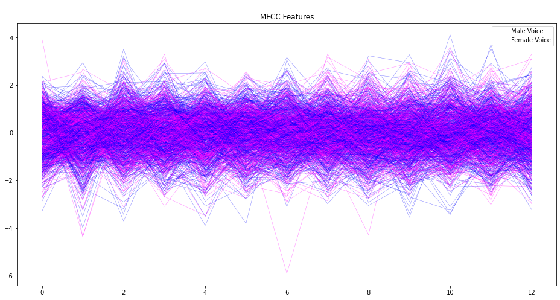

```python
# Plot to visualize the features as signals

# PLot area
plt.figure(figsize = (16, 8))

# Loop through the features
for i in range(1, 540000, 1000):
    plt.plot(features_male[i], c = 'blue', linewidth = 0.5, alpha = 0.5)
    plt.plot(features_female[i], c = 'magenta', linewidth = 0.5, alpha = 0.5)

# Plot
plt.plot(features_male[i+1], c = 'blue', label = 'Male Voice', linewidth = 0.5, alpha = 0.5)
plt.plot(features_female[i+1], c = 'magenta', label = 'Female Voice', linewidth = 0.5, alpha = 0.5)
plt.legend()
plt.title('\nMFCC Features')
plt.show()
```

## Testing Model with Training Dataset (reverse heresy)

```python
# List to receive output
output_male = []
```

```python
%%time
# Loop through the MFCC features for the male voices
# Testing them on both (male and female) models
for f in features_m:

    # Apply the male voice model
    log_likelihood_male = np.array(model_gmm_m_2.score([f])).sum()

    # Apply the female voice model
    log_likelihood_female = np.array(model_gmm_f_2.score([f])).sum()

    # Check which model has the grater probability and assign the gender
    # Using 0 (zero) as truth here helps later on with calculating accuracy
    if log_likelihood_male > log_likelihood_female:
        output_male.append(0)
    else:
        output_male.append(1)
```

```
Wall time: 11.2 s
```

```python
# Accuracy
acc_m_2 = (1 - sum(output_male) / len(output_male))
print('Model Accuracy Recognizing Male Voices: ', acc_m_2)
```

```
Model Accuracy Recognizing Male Voices:  0.6503695846730086
```

```python
# List to receive output
output_female = []
```

```python
%%time
# Loop through the MFCC features for the male voices
# Testing them on both (male and female) models
for f in features_f:

    # Apply the male voice model
    log_likelihood_male = np.array(model_gmm_m_2.score([f])).sum()

    # Apply the female voice model
    log_likelihood_female = np.array(model_gmm_f_2.score([f])).sum()

    # Check which model has the grater probability and assign the gender
    # Using 0 (zero) as truth here helps later on with calculating accuracy
    if log_likelihood_female > log_likelihood_male:
        output_female.append(0)
    else:
        output_female.append(1)
```

```
Wall time: 11 s
```

```python
# Accuracy
acc_f_2 = (1 - sum(output_female) / len(output_female))
print('Model Accuracy Recognizing Female Voices: ', acc_f_2)
```

```
Model Accuracy Recognizing Female Voices:  0.701879261599867
```

Both the male and female models improved with the biggest dataset. Not a big surprise considering that I'm using small datasets.

# Real Time Voice Recognition

```python
# Function to record audio and recognize gender in real time
def real_time_gender_recognition(sr = 16000, channels = 1, duration = 3, filename = 'temp/voice.wav'):

    # Record voice
    audio_record = sd.rec(int(duration*sr), samplerate = sr, channels = channels).reshape(-1)

    # Wait conclusion
    sd.wait()

    # Extract MFCC features
    mfcc_features = extract_mfcc(sr, audio_record)

    # Initialize the score variable
    scores = None

    # Apply the models
    log_likelihood_m = np.array(model_gmm_m_2.score(mfcc_features)).sum()
    log_likelihood_f = np.array(model_gmm_f_2.score(mfcc_features)).sum()

    # Check which model had the highest probability and assign gender
    if log_likelihood_m >= log_likelihood_f:
        return('Male Voice')
    else:
        return('Female Voice')
```

```python
# Execute function
real_time_gender_recognition()
```

```
'Male Voice'
```